# Data wrangling with dplyr

David Hope

2015-12-9

# Introduction to Dplyr

### I suggest you check out Sean Anderson’s excellent tutorial at:

### http://seananderson.ca/2014/09/13/dplyr-intro.html

Also, I keep on my desktop for continual use: http://www.rstudio.com/wp-content/uploads/2015/02/data-wrangling-cheatsheet.pdf

For today, we will just run through a basic script I created to summarize my shorebird survey data and to blend several site surveys into a single value.

First step, load the required packages.

```r
### Script to import all datasets from python output ####
# rm(list = ls())
library(ggplot2)
library(ggthemes)
require(plyr)
library(dplyr)
```

Then we can load in the data. The data shown here is cleaned data from the first 3 years of my shorebird survey. I also have a separate table that describes each site in size, shape and gives the full name.

```r
database.loc <- '~/Dropbox/SFU/ShorebirdSurveyDatabase/'


wesa.counts.cleaned <- read.csv(paste(database.loc, 'Rscripts/wesa_cleaned.txt',sep = ""), sep = '\t', header = T)

wesa.counts.cleaned$count.numeric <- as.numeric(wesa.counts.cleaned$Count_cleaned)

site.codes <- read.csv(paste(database.loc, 'AreaCalculations/AreaComparison.csv', sep = ""),
                       stringsAsFactors = FALSE)
```

With dplyr we can look at the data much more cleanly than with the regular print function.

```r
print(dplyr::tbl_df(wesa.counts.cleaned))
```

```
## Source: local data frame [4,769 x 13]
##
##       X SiteID              ID    RecordID   Time Ratio Ratio_LESA
## 1  1856   NANO  NANO2013721_W1 NANO2013721 '12:00
## 2  4395   NJEN  NJEN2013818_W2 NJEN2013818 '10:15
## 3  3960   PEDD  PEDD2013720_W3 PEDD2013720    830
## 4   785   SDNY SDNY2013818_W11 SDNY2013818   1430
## 5  3399   SDNY SDNY2013818_W10 SDNY2013818   1415
## 6   515   SDNY  SDNY2013818_W9 SDNY2013818   1400
## 7   874   SDNY  SDNY2013818_W6 SDNY2013818   1315
## 8  2029   SDNY  SDNY2013818_W7 SDNY2013818   1330
## 9  3461   SDNY  SDNY2013818_W8 SDNY2013818   1345
## 10 4463   BB04  BB042013818_W3 BB042013818 '14:45
## ..  ...    ...             ...         ...    ...   ...        ...
## Variables not shown: Ratio_WESA (fctr), CountNum (int), Count (fctr),
##   count.w.zeros (fctr), Count_cleaned (dbl), count.numeric (dbl)
```

This output only shows the top few rows and often will clip out columns if the table is too wide. I prefer str() to describe a dataframe.

```r
str(wesa.counts.cleaned)
```

```
## 'data.frame':    4769 obs. of  13 variables:
##  $ X            : int  1856 4395 3960 785 3399 515 874 2029 3461 4463 ...
##  $ SiteID       : Factor w/ 40 levels "ALHE","BB04",..: 25 26 27 33 33 33 33 33 33 2 ...
##  $ ID           : Factor w/ 4769 levels "ALHE2013719_W1",..: 2828 3007 3114 3851 3850 3859 3856 3857 3858 93 ...
##  $ RecordID     : Factor w/ 446 levels "ALHE2013719",..: 264 280 291 362 362 362 362 362 362 9 ...
##  $ Time         : Factor w/ 416 levels "","0:00","0.024305556",..: 160 102 376 210 204 198 186 191 195 219 ...
##  $ Ratio        : Factor w/ 71 levels "","0","0;0","0:0",..: 1 1 1 1 1 1 1 1 1 1 ...
##  $ Ratio_LESA   : Factor w/ 19 levels "","?","0","1",..: 1 1 1 1 1 1 1 1 1 1 ...
##  $ Ratio_WESA   : Factor w/ 37 levels "","?","0","1",..: 1 1 1 1 1 1 1 1 1 1 ...
##  $ CountNum     : int  1 2 3 11 10 9 6 7 8 3 ...
##  $ Count        : Factor w/ 385 levels "","0","0 WESA 0 LESA",..: 385 384 383 345 345 328 313 313 313 295 ...
##  $ count.w.zeros: Factor w/ 384 levels "0","0 WESA 0 LESA",..: 384 383 382 344 344 327 312 312 312 294 ...
##  $ Count_cleaned: num  0 0 9 78 78 69 64 64 64 600 ...
##  $ count.numeric: num  0 0 9 78 78 69 64 64 64 600 ...
```

## Lets summarize the data.

The original data is a series of repeated counts for each date and at each site. I want to turn this into a table that gives a single abundance value for each date and site.

To do this using the normal r coding, it would look something like this:

```
wesa.counts.cleaned$count.numeric <- as.numeric(wesa.counts.cleaned$Count_cleaned)
wesa.removed.nas <- subset(wesa.counts.cleaned, !is.na(count.numeric), select = c(SiteID, RecordID, count.numeric)
aggdata <-aggregate(wesa.removed.nas,
  by=list(wesa.removed.nas$SiteID, wesa.removed.nas$RecordID),
  FUN = max, na.rm = T)
aggdata$Year <- substr(aggdata$RecordID, 5,8)
aggdata$Month <- substr(aggdata$RecordID, 9,9)
aggdata$Day <- substr(aggdata$RecordID, 10,11)
final.counts <- merge(aggdata, site.codes, by = 'SiteID')
str(final.counts)
```

To be honest, I could not get it to work. This is the general idea. The two problems dplyr really solves is to avoid having to reenter the dataframe name repeatedly and to make a much cleaner version of the aggregate function.

To create the same dataframe using dplyr we use the following code:

```r
# SUMMARY BY DATE
wesa.summary <-
  wesa.counts.cleaned %>%
  mutate(count.numeric = as.numeric(Count_cleaned)) %>%
  filter(RecordID != 'RecordID' & !is.na(count.numeric)) %>%
  group_by(RecordID) %>%
  dplyr::summarize(max.count = max(count.numeric, na.rm=T),
            avg.count = mean(count.numeric, na.rm=T),
            sd.count = sd(count.numeric, na.rm = T),
            sum.count = sum(count.numeric, na.rm = T),
            n.counts = n() )%>%
  mutate(SiteID = substr(RecordID, 1, 4),
         Year = substr(RecordID, 5, 8),
         Month = substr(RecordID, 9,9),
         Day = substr(RecordID, 10, 11)) %>%
  left_join(site.codes, by = 'SiteID')
```

The code contains a key piece that makes the code easy to use and readable: `%>%`. This is a ‘pipe’. It basically takes the output from the left-had side and shoves it into the right hand function. For example:

```r
c('The', 'dad', 'threw', 'the', 'baby') %>% cat('in the air\n')
```

```
## The dad threw the baby in the air
```

It is extremely useful for chaining a series of functions without having to create temporary objects. There are several dplyr functions which are fairly self explanitory. I use filter most often as it is much more readable than subset. The dplyr cheat sheet has some good examples of ways to use filter.

Another good function is summarize. You can spell it as an american or brit, but either way it works best combined with `group_by()`. Group_by, well groups the data set based on the values in the named columns. So to summarize the wesa data by month for each year, we would use `group_by(Month, Year)`. This then is piped into the summarize function, which allows you to create a summary table. For example if I wanted the largest single count for the surveys in each year for both July and August, I just have to use the code:

```r
wesa.summary %>% # original data set, piped to grouping function
    group_by(Month, Year) %>% # Group by month and year send to summarize function
    dplyr::summarize(record.count = max(max.count)) # use the dplyr:: to avoid plyr's function which removes other columns
```

```
## Source: local data frame [6 x 3]
## Groups: Month
##
##   Month Year record.count
## 1     7 2013          750
## 2     7 2014         5500
## 3     7 2015         2500
## 4     8 2013         2000
## 5     8 2014         7500
## 6     8 2015         4700
```

Mutate is a good way to create new columns from previous ones. It replaces `df$new.column <- df$col1 + df$col2`. It is mostly useful when creating several columns at once.

The final function used here is `left_join()`. If you’ve used sql or any sort of database code, this will be familiar. Basically there are three main joins: Left, Right and Full. Left join, keeps all the values from the first dataframe and populates the columns from the right dataframe into it using the values in a given column. In this case I use the site codes to assign the estimated area, and full name to the row. Right join does the opposite and full join keeps all rows from both data frames.

For example:

```
##      X SiteID             ID    RecordID   Time Ratio Ratio_LESA
## 1 1856   NANO NANO2013721_W1 NANO2013721 '12:00
##   Ratio_WESA CountNum Count count.w.zeros Count_cleaned count.numeric
## 1                   1  Zero          Zero             0             0
```

```
##      X SiteID             ID    RecordID   Time Ratio Ratio_LESA
## 1 1856   NANO NANO2013721_W1 NANO2013721 '12:00
##   Ratio_WESA CountNum Count count.w.zeros Count_cleaned count.numeric
## 1                   1  Zero          Zero             0             0
##      SiteName  OnlineName   size area.google.earth area.gis Ratio.GIS.GE
## 1 Nanoose Bay Nanoose bay Medium           1111699  1107259    0.9960061
##   Alt_Area.GE
## 1          NA
```

You can see from the second output, we have appended the correct site information based on the SiteID value.

Overall, I’d say the filter, and group_by/summarise functions are ones I use regularily and always with a pipe.

## Merge sites using grep

Another way I used dplyr was to take all the sites surveyed along Boundary Bay and convert it into a single value. To do this I used `grepl()`, which searches a column and in conjunction with `filter()` pulls out rows that match the search term.

```r
  # Time counts at boundary bay

bb <-
  wesa.counts.cleaned %>%
  filter(grepl(pattern = '^BB', SiteID )) %>%
  select(ID, RecordID, CountNum,Time, SiteID, count.numeric) %>%
  mutate(SiteID = substr(RecordID, 1, 4),
         Year = substr(RecordID, 5, 8),
         Month = substr(RecordID, 9,9),
         Day = substr(RecordID, 10, 11),
         datecode = paste(Year, Month, Day, sep = "")) %>%
  arrange(datecode, CountNum, SiteID)
```

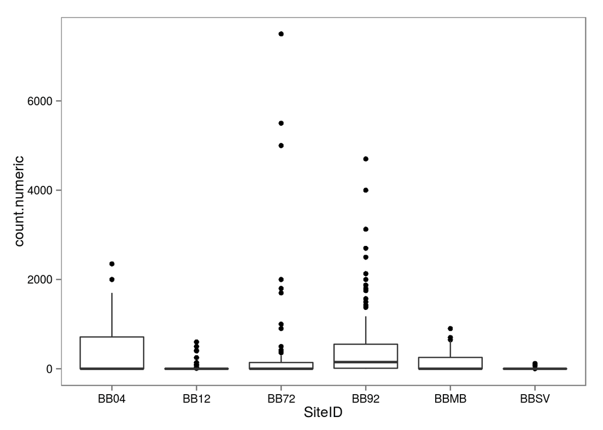

To combine each count into a single value for the entire bay, I need to group by the survey date and the individual counts. Then I can sum or average accross the sites as is needed for my analysis.

```r
bb.final.sum <-
  bb %>%
  group_by(datecode, CountNum, Year, Month, Day) %>%
  dplyr::summarize(sum.count = sum(count.numeric),
                 avg.count = mean(count.numeric),
                 max.count = max(count.numeric),
                 number.sites = n(),
                 SiteID = 'BBAY',
                 SiteName = 'Boundary Bay',
                 sd.count = sd(count.numeric),
                 RecordID = paste(SiteID, datecode, sep = "")) %>%
    group_by(RecordID) %>%
    dplyr::summarize(max.count = max(sum.count, na.rm=T),
                     avg.count = mean(sum.count, na.rm=T),
                     sd.count = sd(sum.count, na.rm = T),
                     sum.count = sum(sum.count, na.rm = T),
                     n.counts = n() )%>%
    mutate(SiteID = substr(RecordID, 1, 4),
           Year = substr(RecordID, 5, 8),
           Month = substr(RecordID, 9,9),
           Day = substr(RecordID, 10, 11))%>%
  left_join(site.codes, by = 'SiteID')
```

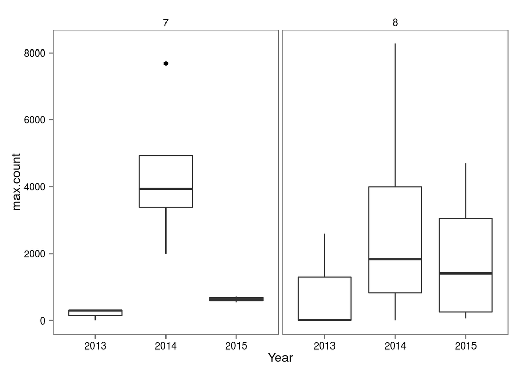

This final data set can then be used to create a new data frame that contains only a single daily value for all of Boundary Bay.

```r
wesa.w.large.sites <-
  wesa.summary %>%
  filter(!grepl(pattern = '^BB', SiteID )) %>%
  full_join(bb.final.sum)
```